# Versicherung_Use_case_final

Dr. Houssam Jedidi

2025-04-12

# Einführung

In dieser Analyse untersuchen wir Versicherungsdaten und trainieren verschiedene Machine-Learning-Modelle, um die Versicherungsaufwendungen (**expenses**) vorherzusagen. Dabei nutzen wir die Konzepte der **Recipes** und **Workflows**, um unsere Datenvorverarbeitung und das Training zu strukturieren.

**Recipes**: - Ein **Recipe** beschreibt die Schritte der Datenvorverarbeitung, z. B. die Handhabung fehlender Werte, das Skalieren von Features oder die Erstellung von Dummy-Variablen. - Recipes sorgen für eine saubere Trennung zwischen Vorverarbeitung und Modelltraining.

**Workflows**: - Ein **Workflow** kombiniert ein Recipe und ein Modell, um alle Schritte – von der Datenvorbereitung bis zum Modelltraining – konsistent und reproduzierbar auszuführen.

# 2 Packages

```r
# install.packages("mice")
# install.packages("rpart")
# install.packages("tidymodels")
#install.packages("rlang")
```

# 3 Libraries

# 4 Datensatz

# 5 EDA

```r
insurance %>% skim()
```

Data summary

| Name | Piped data |
| --- | --- |
| Number of rows | 1338 |
| Number of columns | 7 |
| _______________________ |  |
| Column type frequency: |  |
| character | 3 |
| numeric | 4 |
| ________________________ |  |
| Group variables | None |

**Variable type: character**

| skim_variable | n_missing | complete_rate | min | max | empty | n_unique | whitespace |
| --- | --- | --- | --- | --- | --- | --- | --- |
| sex | 0 | 1 | 4 | 6 | 0 | 2 | 0 |
| smoker | 0 | 1 | 2 | 3 | 0 | 2 | 0 |
| region | 0 | 1 | 9 | 9 | 0 | 4 | 0 |

**Variable type: numeric**

| skim_variable | n_missing | complete_rate | mean | sd | p0 | p25 | p50 | p75 | p100 | hist |
| --- | --- | --- | --- | --- | --- | --- | --- | --- | --- | --- |
| age | 0 | 1.00 | 39.21 | 14.05 | 18.00 | 27.00 | 39.00 | 51.00 | 64.00 | ▇▅▅▆▆ |
| bmi | 187 | 0.86 | 30.61 | 6.19 | 16.00 | 26.10 | 30.30 | 34.80 | 53.10 | ▂▇▇▂▁ |
| children | 0 | 1.00 | 1.09 | 1.21 | 0.00 | 0.00 | 1.00 | 2.00 | 5.00 | ▇▂▂▁▁ |
| expenses | 0 | 1.00 | 13270.42 | 12110.01 | 1121.87 | 4740.29 | 9382.03 | 16639.92 | 63770.43 | ▇▂▁▁▁ |

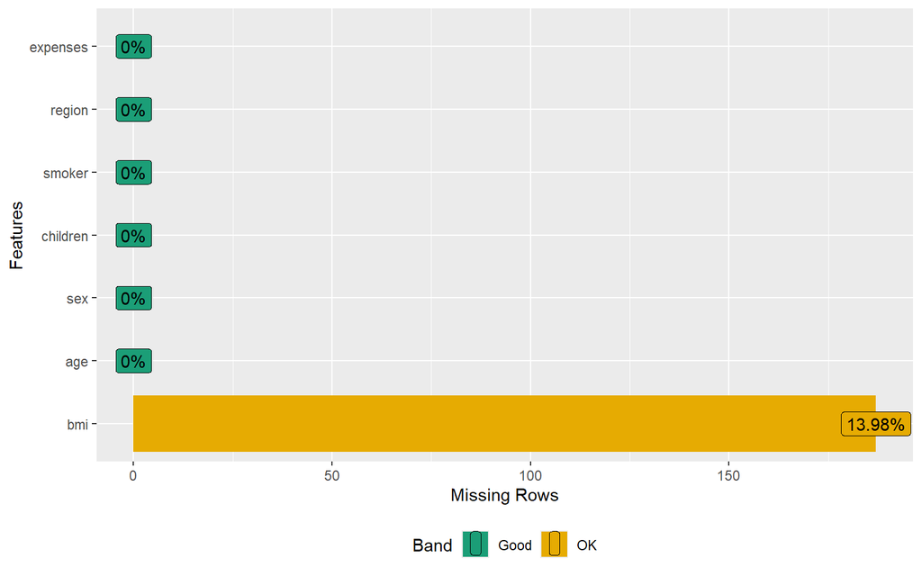

```r
insurance %>% plot_missing()
```

Imputation Mithilfe der Bayesische Lineare Regression (norm.nob)

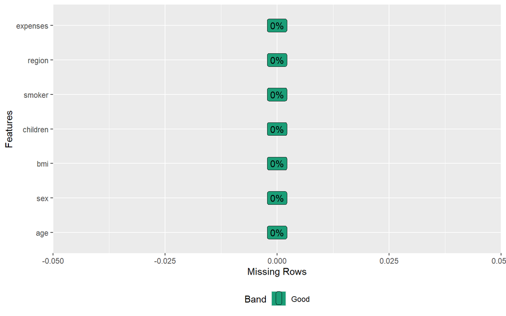

```r
imputed_df %>% plot_missing()
```

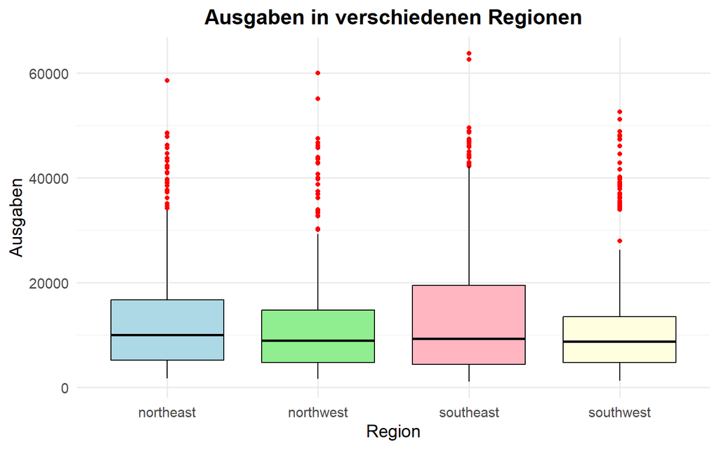

```r
library(ggplot2)
# Beispiel für Ihren ggplot Boxplot
ggplot(imputed_df, aes(x = region, y = expenses, fill = region)) +
  geom_boxplot(color = "black", outlier.color = "red", outlier.shape = 16) +
  scale_fill_manual(values = c("lightblue", "lightgreen", "lightpink", "lightyellow")) +
  labs(
    title = "Ausgaben in verschiedenen Regionen",
    x = "Region",
    y = "Ausgaben"
  ) +
  theme_minimal(base_size = 14) +
  theme(
    plot.title = element_text(hjust = 0.5, face = "bold"),
    legend.position = "none"
  )
```

# Außreißer Detection

```r
# Ausreißer-Werte extrahieren
bp <- boxplot(imputed_df$expenses, plot = FALSE)

outliers <- imputed_df[imputed_df$expenses %in% bp$out, ]
print(outliers)
```

```
##      age    sex      bmi children smoker    region expenses
## 15    27   male 42.10000        0    yes southeast 39611.76
## 20    30   male 35.30000        0    yes southwest 36837.47
## 24    34 female 43.59912        1    yes northeast 37701.88
## 30    31   male 36.30000        2    yes southwest 38711.00
## 31    22   male 35.60000        0    yes southwest 35585.58
## 35    28   male 36.40000        1    yes southwest 51194.56
## 39    35   male 36.70000        1    yes northeast 39774.28
## 40    60   male 41.98157        0    yes southwest 48173.36
## 50    36   male 35.20000        1    yes southeast 38709.18
## 54    36   male 34.40000        0    yes southeast 37742.58
## 56    58   male 37.00000        2    yes northwest 47496.49
## 83    22   male 37.60000        1    yes southeast 37165.16
## 85    37 female 34.80000        2    yes southwest 39836.52
## 87    57 female 31.20000        0    yes northwest 43578.94
```

[output cut: 125 more lines]

Nun ist unser Datensatz vollständig und wir Können das ML-workdflow starten

# 6 Splitting Datensatz für ML

```r
# Split in Train und Test Sets
set.seed(123)
split_data <- initial_split(imputed_df, prop = 0.7, strata = "expenses") # strata
train_data <- training(split_data)
test_data <- testing(split_data)
```

# 7 Erstellen eines Rezepts

```r
insurance_recipe <- recipe(expenses ~ ., data = train_data) %>%
  step_impute_knn(all_predictors()) %>%
  step_string2factor(all_nominal_predictors()) %>%
  step_dummy(all_nominal_predictors()) %>%
  step_center(all_numeric_predictors()) %>%
  step_scale(all_numeric_predictors())
```

# 8 Allg. Workflow erstellen

–> Vermeidung von Bake und Prep –> Automatisierung

```r
# Workflow erstellen und das Rezept hinzufügen
insurance_workflow <- workflow() %>%
  add_recipe(insurance_recipe)
```

# 9 Lineares Modell mit Workflow

```r
# Hinzufügen des linearen Modells zum Workflow
lm_workflow <- insurance_workflow %>%
  add_model(linear_reg() %>% set_engine("lm"))

# Trainieren des Workflows mit dem linearen Modell
lm_fit <- lm_workflow %>%
  fit(data = train_data)

# Vorhersagen auf den Testdaten
lm_predictions <- lm_fit %>%
  predict(new_data = test_data) %>%
  bind_cols(test_data)

# Berechnung der RMSE für das lineare Modell
lm_rmse <- lm_predictions %>%
  mutate(error = .pred - expenses) %>%
  summarise(rmse = sqrt(mean(error^2))) %>%
  pull(rmse)

cat("Root Mean Squared Error (Linear Regression):", lm_rmse, "\n")
```

```
## Root Mean Squared Error (Linear Regression): 6237.185
```

# 10 Support Vector Machine (SVM) mit Workflow und Hyperparameter-Tuning

Erklärung der Parameter: Die Kreuzvalidierung wird mit einer Rastersuche für Hyperparameter kombiniert. In deinem Fall sind die Hyperparameter C und Sigma, die für die SVM mit radialer Kernel-Funktion relevant sind. Die Rastersuche durchläuft verschiedene Kombinationen von C- und Sigma-Werten und wählt diejenigen aus, die die beste Leistung auf den Validierungssets zeigen:

C: Der Parameter C ist der Kostenparameter (Cost), der die Strafe für Fehler auf Trainingsdaten kontrolliert. Ein kleines C führt zu einem weichen (soft) Margin, was bedeutet, dass das Modell mehr Fehler auf den Trainingsdaten zulässt, um eine glattere Entscheidungsgrenze zu erhalten. Ein großes C führt zu einem harten (hard) Margin, wodurch das Modell versucht, alle Trainingsdaten korrekt zu klassifizieren, auch wenn dies zu einer unebenen Entscheidungsgrenze führen kann.

Sigma: ist der Parameter, der die Breite des radialen Basisfunktionen-Kernels steuert. Eine kleinere Sigma-Wert führt zu schärferen, spitzen Entscheidungsgrenzen und kann zu einer Überanpassung führen. Ein größerer Sigma-Wert führt zu glatteren Entscheidungsgrenzen, was zu einer besseren Generalisierung, aber möglicherweise auch zu einer geringeren Empfindlichkeit des Modells führen kann.

```r
# Lade das caret-Paket für maschinelles Lernen
library(caret)

# Definiere die Steuerung für eine Kreuzvalidierung mit Rastersuche
ctrl <- trainControl(method = "cv", number = 10)

# Definiere das Raster für die Hyperparameter C und Sigma
grid <- expand.grid(C = c(0.1, 1, 10, 100),
                   sigma = c(0.01, 0.1, 1, 10))

# Führe die Rastersuche durch und trainiere das SVM-Modell mit radialer Kernel-Funktion
        #Flexibilität: Der RBF-Kernel ist flexibel und kann nicht-lineare Beziehungen zwischen den Features und
        #der Zielvariable abbilden. Das ermöglicht die Erfassung von komplexen Muster in den Daten.

        #Vielseitigkeit:
        #komplexe und nichtlineare Entscheidungsgrenzen zu modellieren

# fit <- train(expenses ~ ., data = prepped_train_data, method = "svmRadial",
#              trControl = ctrl, tuneGrid = grid)
#
# test_fit<- train(my_first_recipe,data = train_data, method = "svmRadial",
#              trControl = ctrl, tuneGrid = grid)
# summary(test_fit)
# # Gib eine Zusammenfassung des besten Modells aus
# summary(fit)

tic()
fit<- caret::train(insurance_recipe,
            data = train_data,
            method = "svmRadial",
            trControl = ctrl,
            tuneGrid = grid
            )
toc()
```

```
## 17.05 sec elapsed
```

```r
prediction_fit<- predict(fit, newdata=test_data)

performance <- sqrt(mean((prediction_fit - test_data$expenses)^2))
cat("Root Mean Squared Error (SVM):", performance, "\n")
```

```
## Root Mean Squared Error (SVM): 5220.978
```